# Treasury Constant Maturity Rate vs. Japanese Government Bonds Interest Rate

アセット･マネジメント･コンサルティング株式会社 http://am-consulting.co.jp

2017-03-15 12:40:49

- アセット･マネジメント･コンサルティング株式会社 http://am-consulting.co.jp
- SaECaNet http://saecanet.com/
- Olive http://olive.saecanet.com/
- twitter https://twitter.com/AMC2_Japan
- 本ページへのリンクを共有:[Tweet](https://twitter.com/share)
- タイトル : 日米国債金利差
- データ出所 : 財務省、Federal Reserve Bank of St.Louis
- DGS:Daily Treasury Constant Maturity Rate(%)
- JGB:Japanese Government Bonds Interest Rate(%)

#### Interest-rate difference between DGS and JGB

**01-Year Treasury Constant Maturity Rate(%) - JGB-1Y(%)**  
1974-09-24 ~ 2017-03-13

| Min. | 1st Qu. | Median | Mean | 3rd Qu. | Max. |
| --- | --- | --- | --- | --- | --- |
| -5.542 | 0.171 | 1.85 | 2.109 | 4.265 | 9.141 |

**02-Year Treasury Constant Maturity Rate(%) - JGB-2Y(%)**  
1976-06-01 ~ 2017-03-13

| Min. | 1st Qu. | Median | Mean | 3rd Qu. | Max. |
| --- | --- | --- | --- | --- | --- |
| -3.197 | 0.67 | 2.409 | 2.568 | 4.23 | 8.452 |

**03-Year Treasury Constant Maturity Rate(%) - JGB-3Y(%)**  
1974-09-24 ~ 2017-03-13

| Min. | 1st Qu. | Median | Mean | 3rd Qu. | Max. |
| --- | --- | --- | --- | --- | --- |
| -3.171 | 0.904 | 2.38 | 2.486 | 4.087 | 8.095 |

**05-Year Treasury Constant Maturity Rate(%) - JGB-5Y(%)**  
1974-09-24 ~ 2017-03-13

| Min. | 1st Qu. | Median | Mean | 3rd Qu. | Max. |
| --- | --- | --- | --- | --- | --- |
| -2.994 | 1.405 | 2.622 | 2.602 | 3.918 | 7.876 |

**07-Year Treasury Constant Maturity Rate(%) - JGB-7Y(%)**  
1974-09-24 ~ 2017-03-13

| Min. | 1st Qu. | Median | Mean | 3rd Qu. | Max. |
| --- | --- | --- | --- | --- | --- |
| -2.581 | 1.626 | 2.661 | 2.629 | 3.836 | 6.756 |

**10-Year Treasury Constant Maturity Rate(%) - JGB-10Y(%)**  
1986-07-07 ~ 2017-03-13

| Min. | 1st Qu. | Median | Mean | 3rd Qu. | Max. |
| --- | --- | --- | --- | --- | --- |
| 0.634 | 1.844 | 2.684 | 2.644 | 3.388 | 5.088 |

**20-Year Treasury Constant Maturity Rate(%) - JGB-20Y(%)**  
1993-10-01 ~ 2017-03-13

| Min. | 1st Qu. | Median | Mean | 3rd Qu. | Max. |
| --- | --- | --- | --- | --- | --- |
| 0.506 | 1.946 | 2.735 | 2.636 | 3.401 | 4.598 |

**30-Year Treasury Constant Maturity Rate(%) - JGB-30Y(%)**  
1999-09-02 ~ 2017-03-13

| Min. | 1st Qu. | Median | Mean | 3rd Qu. | Max. |
| --- | --- | --- | --- | --- | --- |
| 0.385 | 1.597 | 2.124 | 2.146 | 2.507 | 4.271 |

#### 10年物金利差と米ドル為替レート

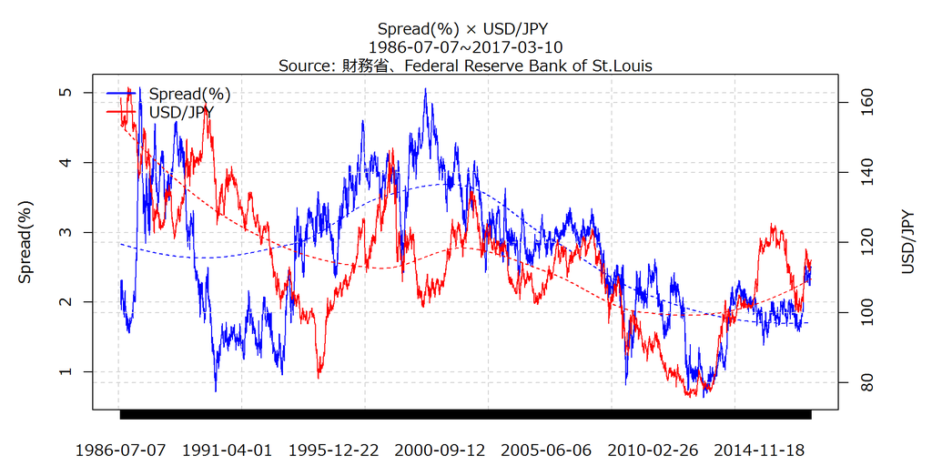

- 2016年大統領選挙以降

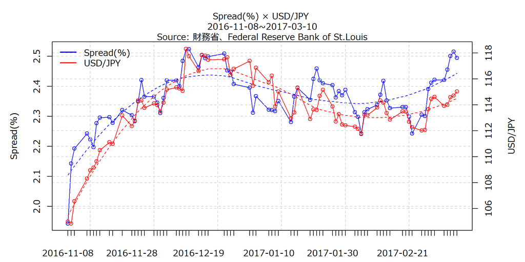

#### 01-Year Treasury Constant Maturity Rate(%) × JGB-1Y(%)

[interactive chart not shown]

#### 02-Year Treasury Constant Maturity Rate(%) × JGB-2Y(%)

[interactive chart not shown]

#### 03-Year Treasury Constant Maturity Rate(%) × JGB-3Y(%)

[interactive chart not shown]

#### 05-Year Treasury Constant Maturity Rate(%) × JGB-5Y(%)

[interactive chart not shown]

#### 07-Year Treasury Constant Maturity Rate(%) × JGB-7Y(%)

[interactive chart not shown]

#### 10-Year Treasury Constant Maturity Rate(%) × JGB-10Y(%)

[interactive chart not shown]

#### 20-Year Treasury Constant Maturity Rate(%) × JGB-20Y(%)

[interactive chart not shown]

#### 30-Year Treasury Constant Maturity Rate(%) × JGB-30Y(%)

[interactive chart not shown]

| Item | 2017-03-08 | 2017-03-09 | 2017-03-10 | 2017-03-13 |
| --- | --- | --- | --- | --- |
| 01-Year Treasury Constant Maturity Rate(%) - JGB-1Y(%) | 1.353 | 1.358 | 1.358 | 1.385 |
| 02-Year Treasury Constant Maturity Rate(%) - JGB-2Y(%) | 1.65 | 1.639 | 1.624 | 1.659 |
| 03-Year Treasury Constant Maturity Rate(%) - JGB-3Y(%) | 1.852 | 1.852 | 1.839 | 1.865 |
| 05-Year Treasury Constant Maturity Rate(%) - JGB-5Y(%) | 2.224 | 2.244 | 2.229 | 2.255 |
| 07-Year Treasury Constant Maturity Rate(%) - JGB-7Y(%) | 2.447 | 2.472 | 2.445 | 2.471 |
| 10-Year Treasury Constant Maturity Rate(%) - JGB-10Y(%) | 2.501 | 2.516 | 2.495 | 2.535 |
| 20-Year Treasury Constant Maturity Rate(%) - JGB-20Y(%) | 2.219 | 2.268 | 2.259 | 2.293 |
| 30-Year Treasury Constant Maturity Rate(%) - JGB-30Y(%) | 2.301 | 2.345 | 2.302 | 2.337 |